# Appendix S9: Estimating biphasic growth for multiple populations with an environmental trend using MCMC

Kyle L. Wilson The University of Calgary

October 5, 2017

## Summary description of objectives:

This appendix is in support of Wilson *et al.* (2017). The citation style language (csl) used herein is the methods-in-ecology-and-evolution.csl file which can be downloaded from https://github.com/citation-style-language/styles/blob/master/methods-in-ecology-and-evolution.csl and placed in the same directory as this .rmd file.

The following is an example application of the Lester biphasic model (Lester, Shuter & Abrams 2004) where the breakpoint $T$ (age-at-maturity) is treated as unknown prior to model estimation. There is an environmental trend on growth (e.g., Helser & Lai (2004)). Hence, this serves as an example of how to estimate an environmental determinant on a life history trait of interest, while accounting for uncertainty in both the trait itself and the relationship with its environment.

Specifically, we simulate multiple populations, and the life history of each population is related to that of other populations in a hierarchical manner (i.e., each life history parameter is random arising from a global distribution for that life history parameter). Known growth parameters are used to simulate the random, population-specific parameters. We also simulate an environmental trend on the parameter $h$ (juvenile growth rate) whereby growth increases across a gradient (labeled `enviro` in the code below). We generate size-at-age data given a population-specific, constant coefficient of variation in size-at-age.

We then fit the Lester biphasic model to these simulated data using a hierarchical framework in the Bayesian MCMC software JAGS. This framework allows us to estimate population-specific and ‘global’ (i.e., average across populations) growth parameters, as well as the slope of the environmental effect on $h$ among populations. We build the hierarchical model with vague priors (or hyperpriors), and we run JAGS from the R console using the `runjags` package and `run.jags()` function. JAGS must be installed independently prior to running this code (see ‘http://mcmc-jags.sourceforge.net/’). All variables are treated as unknown at both the population and ‘global’ levels.

Our results summarize variables by their marginal posterior distribution. We then compare the central tendency of each parameter’s posterior distribution to determine how well we recover the simulated ‘true’ parameters at the population and global levels. Lastly, we evaluate our ability to detect the environmental trend in $h$.

## Global functions

First, we will define a few global functions that will be used later.

```r
Corner_text <- function(text, location="topright") #function to write text to the corner of plots
{
  legend(location,legend=text, bty ="n", pch=NA)
}

get_beta <- function(mean,cv) #function that returns the alpha and beta shape parameters of a beta distribution, based on the mean and variation of a given beta distribution
{
  sd <- mean*cv
  alpha <- -((mean*(mean^2+sd^2-mean))/sd^2)
  beta <- alpha/mean-alpha
  return(list(alpha=alpha,beta=beta))
}

panel.cor <- function(x, y, digits = 2, prefix = "", cex.cor, ...)
{
  usr <- par("usr"); on.exit(par(usr))
  par(usr = c(0, 1, 0, 1))
  r <- abs(cor(x, y))
  txt <- format(c(r, 0.123456789), digits = digits)[1]
  txt <- paste0(prefix, txt)
  if(missing(cex.cor)) cex.cor <- 0.8/strwidth(txt)
  text(0.5, 0.5, txt, cex = cex.cor * r)
}

rngList <- function(x,y){ #this function creates randomly 'jittered' starting values for each MCMC chain
  lis <- lapply(x, lapply, length) #get the lower order dimensions of the list x
  names(lis) <- lapply(x, length) #get the names of those dimensions of the list x
  l_el <- length(names(lis)) #get the maximum number elements of the highest order dimensions of the list x
  for(i in 1:(l_el-2)) #loop through those dimensions which need to be 'jittered'
  {
    x[[i]] <- x[[i]]*(1+runif(1,-0.15,0.15)) #jitter values of the list by +/- 15%
  }
  x[[l_el]] <- round(runif(1,1,100000),0) #have a random RNG seed for the MCMC chain
  return(x)
}
```

## Define life history parameters

First, we must load the required libraries. We then start the simulation by specifying how many populations we want to model with `npop`. Then, we specify the leading life history parameters of the growth model: $h$, $t_1$, $M$, $g$, and $cv$. Consistent with the hierarchy of the model, we specify the among-population variation of each life history parameter (e.g., `h_cv` describes the coefficient of variation in the parameter $h$ across all populations). The $cv$ parameter for variation in length-at-age is 15%, consistent with typical observations among fishes Lorenzen (2016).

```r
library(runjags)  #load, install, or require the 'runjags' library
library(rjags)
```

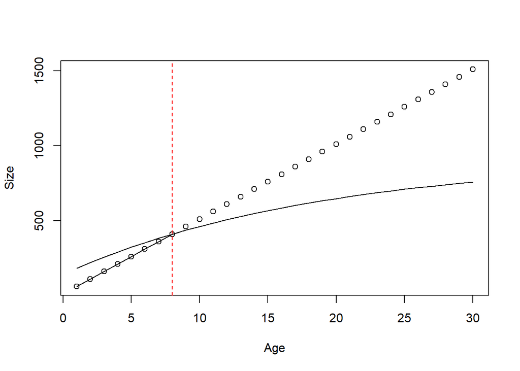

```r
library(coda)
library(stats4)  #load the 'stats4' library
library(corrplot)

nPop <- 10  ## how many populations are there?

ages <- 1:30  #create an integer sequence of ages

Tmat <- 8  # age of maturity
Tmat_cv <- 0.1  # what is the variation in maturity across populations?

h <- 50  # somatic growth in millimeters per year
h_cv <- 0.15  # what is the variation in growth rate across populations?

t1 <- -0.2  #age when size=0 for the juvenile phase
t1_cv <- 0.1  # what is the variation in age when size=0 across populations?

M <- 0.15  #Natural mortality for the population
g <- 1.18 * (1 - exp(-M))  # proportion of energy in adult phase allocated to reproduction per year
g_cv <- 0.01  # what is the variation in g across populations?

cv <- 0.15  # coefficient of variation in size-at-age
sizeCV <- 1e-09  # what is the variation in the CV parameter across populations?
# i.e., are some populations more variable in size-at-age than others?

beta1 <- 0.15  # define the slope between growth rate and environment
enviro <- seq(from = 0, to = 100, length = nPop)  # define the value for the environmental gradient
std.enviro <- (enviro - mean(enviro))  # center the gradient on the mean

linf <- 3 * h/g  # convert to VBGF L-infinity
vbk <- log(1 + g/3)  # convert to VBGF kappa
t0 <- Tmat + log(1 - g * (Tmat - t1)/3)/log(1 + g/3)  #convert to VBGF t0

lena_phase1 <- h * (ages - t1)  # length-at-age for phase 1
lena_phase2 <- linf * (1 - exp(-vbk * (ages - t0)))  # length-at-age for phase 2
biphasic <- ifelse(ages < Tmat, lena_phase1, lena_phase2)  #if-else statement for which phase a fish is allocating surplus energy

plot(ages, lena_phase1, ylab = "Size", xlab = "Age")
lines(ages, lena_phase2)
lines(ages, biphasic)
abline(v = Tmat, col = "red", lty = 2)  #plot where maturity occurs
```

Next, we generate the population-specific life history parameters, which arise as a random variable from that parameter’s distribution. We set the random number generator to 100 so that our results are repeatable: `set.seed(100)`. Note that the population-specific juvenile growth rate $h$ will increase as the environmental gradient increases with a slope of $\beta$, but there is still noise in the relationship:

$$h_i \sim N(\mu, \sigma)$$
with mean $\mu$ and variance $\sigma$ of this distribution defined as

$$\mu = h+\beta*x_i$$
and

$$\sigma = h*cv_\text{h}$$
.

```r
set.seed(100)
h_i <- rnorm(nPop,(h+beta1*std.enviro),h*h_cv) # growth rate, h, for population i is random arising from a normal distribution with mean h and standard deviation of h*h_cv
plot(enviro, h_i, xlab="Environmental covariate",ylab="Juvenile somatic growth rate (mm/yr)")
lines(enviro,(h+beta1*std.enviro),lty=2,lwd=2,col="grey50")
Tmat_i <- rnorm(nPop,Tmat,Tmat*Tmat_cv)
t1_i <- rnorm(nPop,t1,abs(t1*t1_cv))
g_i <- rbeta(nPop,get_beta(g,g_cv)$alpha,get_beta(g,g_cv)$beta) # grab the shape parameters of a beta distribution based on its mean and variance
ifelse(all(g_i < 3/(Tmat_i-t1_i)), # there is a life-hisory constraint on the parameter g
       g_i <- g_i,
       g_i <- rbeta(nPop,get_beta(g,g_cv)$alpha,get_beta(g,g_cv)$beta))
```

```
## [1] 0.1641956
```

```r
cv_i <- rnorm(nPop,cv,cv*sizeCV)

true.par <- list(h=h,T50=Tmat,t1=t1,g=g,sizeCV=cv,
                  h_pop=h_i,T50_pop=Tmat_i,t1_pop=t1_i,g_pop=g_i,
                  h_cv=h_cv,T50_cv=Tmat_cv,t1_cv=t1_cv,g_cv=g_cv)
```

[figure not shown]

## Simulating the data

Next, we make an empty data object which we later fill with our population-specific, randomly generated length-at-age data. We use $M$ to generate each population’s survivorship curve. This allows us to simulate more realistic age-structures (by multipltying $M$ by selectivity). We generate data using a random normal distribution (realized parameter values and model fit quality will change due to randomness) using the `rnorm()` function. Sample sizes expected for each age should be realistic for fisheries data and are determined from a function of gear selectivity and natural mortality (or survivorship) arising from a multinomial process using the `rmultinom()` function.

```r
dataPop <- NULL  # make an empty object that we will fill in later
for (i in 1:nPop) {
    surv <- rep(NA, length(ages))  # create an empty vector
    surv[1] <- 1
    for (j in 2:max(ages)) {
        surv[j] <- surv[j - 1] * exp(log(((g_i[i]/1.18) - 1)/-1))
    }  #survivorship from discrete annual survival
    gearA50 <- Tmat_i[i]  # induce a gear selectivity that inflects at T
    gearSlope <- -0.3  # define the slope of selectivity
    select <- 1/(1 + exp(gearSlope * (ages - gearA50)))  # the average selectivity curve


    linf <- 3 * h_i[i]/g_i[i]  # conversion for the VBGF L-infinity
    vbk <- log(1 + g_i[i]/3)  # conversion for the VBGF parameter kappa
    t0 <- Tmat_i[i] + log(1 - g_i[i] * (Tmat_i[i] - t1_i[i])/3)/log(1 + g_i[i]/3)  #conversion for the VBGF parameter t0
    lena_juv <- h_i[i] * (ages - t1_i[i])  # length-at-age for phase 1
    lena_adult <- linf * (1 - exp(-vbk * (ages - t0)))  # length-at-age for phase 2
    mean_size <- ifelse(ages <= Tmat_i[i], lena_juv, lena_adult)  #if-else statement for which phase a fish is allocating surplus energy

    SampSize <- 10000
    maxSamp <- as.vector(rmultinom(1, prob = surv * select, size = SampSize))  # whats the maximum number of observable samples for an age group in a population?
    # surv*select is the probability of a fish surviving a certain ageand being
    # sampled

    mean.samp <- as.data.frame(cbind(mean_size, maxSamp))  #make matrix of mean lengths-at-age and sample sizes
    mlen <- rep(mean.samp[, 1], mean.samp[, 2])  #repeat each mean 'sample size' number of times
    ageData <- rep(ages, mean.samp[, 2])  #repeat each age 'sample size' number of times
    lengths <- sapply(mlen, function(x) rnorm(1, mean = x, sd = x * cv))  #generate random normal length data using means & cv error
    Data <- data.frame(cbind(ageData, lengths, rep(i, length(ageData))), row.names = NULL)  #bind vectors into age and length matrix, covert to data frame
    colnames(Data) <- c("Age", "Size", "Pop_Num")  # re-name the columns
    Data <- Data[sample(nrow(Data), size = round(runif(1, 40, 200)), replace = F),
        ]  #draw a random sample from the population -- total sample size can be adjusted
    rownames(Data) <- c()
    dataPop <- rbind(dataPop, Data)
}

rownames(dataPop) <- c()
```

Next, we plot the noisy data, with colors assigned to the data coming from each population. We can also take a quick look at some of the data to visualize the data structure.

```
##      Age      Size Pop_Num
## 31    10 401.60220       1
## 1082  11 579.85309      10
## 733    4 183.90674       7
## 860    9 521.21011       8
## 925    6 273.51945       9
## 647   19 590.01397       6
## 423    1  72.59156       4
## 222   10 418.53558       2
## 590   18 753.39073       6
## 954   18 580.49422       9
```

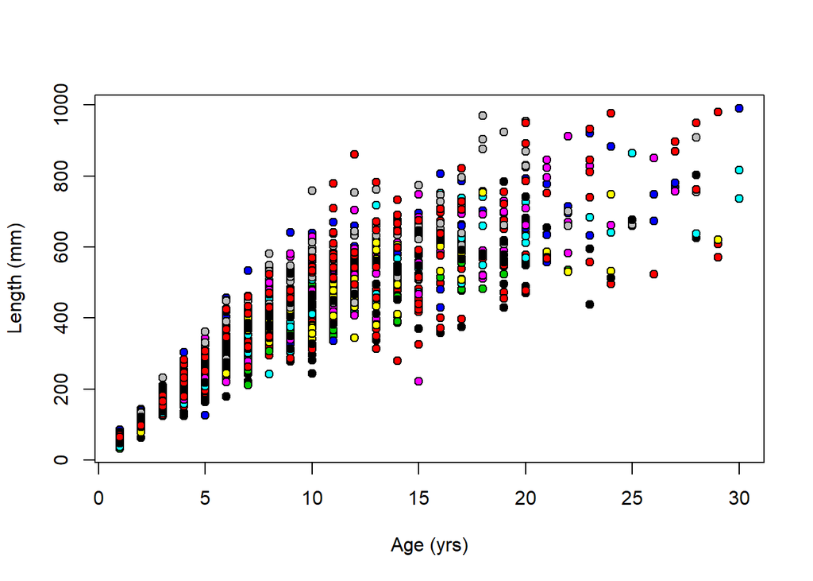

```r
plot(dataPop$Age, dataPop$Size, bg = dataPop$Pop_Num, pch = 21, xlab = "Age (yrs)",
    ylab = "Length (mm)")

dataPop[sample(1:nrow(dataPop), 10), ]
```

## Write the hierarchical model in JAGS

The following code is written in the JAGS language (Plummer 2017). JAGS is fed a list associated with the data. Each data point has an population identification index.

The JAGS model loops through each sample, from *i* to *Nfish*, and determines the contribution of the predicted size of fish *i* to the log-posterior density, which is the sum of the log-likelihood and the log-prior. The predicted growth follows the analytical model from the equations in Lester et al. (2004). There is an if-else statement that determines if the predicted size-at-age of fish *i* comes from the juvenile phase or the adult phase. The priors for each population’s life history trait e.g., $h$ for population *j*, comes from a global hyper-prior for $h$ representing the average across all populations. Modifications to this code will need to use JAGS syntax and not R syntax.

```r
model <- "model {
#run through all the individual fish
for(i in 1:Nfish) {
  size[i] ~ dnorm(pred[i],1/(pred[i]*size.cv)^2)T(0,) # one variability across all populations

  #predict growth for each fish
  juv[i] <- h_pop[Pop[i]]*(age[i]-t1_pop[Pop[i]]) # predicted growth for fish i for the juvenile phase

  # below is the predicted growth for fish i for the adult phase which follows converting Lester et al. (2004) equations into the von Bertalanffy growth function

  adult[i] <- (3*h_pop[Pop[i]]/g_pop[Pop[i]])*(1-exp(-(log(1+g_pop[Pop[i]]/3))*(age[i]-(T50_pop[Pop[i]]+log(1-g_pop[Pop[i]]*(T50_pop[Pop[i]]-t1_pop[Pop[i]])/3)/log(1+g_pop[Pop[i]]/3)))))
  pred[i] <- ifelse(age[i]<=T50_pop[Pop[i]],juv[i],adult[i]) # does the age of fish i exceed the maturity predicted for its population?

} # end the calculation of the likelihood


# priors by population
for(j in 1:Npop) {
  # normal priors for population j
  T50_pop[j] ~ dnorm(T50,tau.T50)T(0,)
  h_pop[j] ~ dnorm(h+wb*beta1*enviro[j],tau.h)T(0,)
  t1_pop[j] ~ dnorm(t1, tau.t1)

  # Beta distribution for the reproductive investment
  #(bounded between 0 and stochastic upper limit)

  g_pop[j] ~ dbeta(beta_alpha,beta_beta)T(,3/(T50_pop[j]-t1_pop[j]))

} # end the priors for each trait by population


# hyper priors on life history traits

T50 ~ dnorm(10,1e-7)T(0,)
h ~ dnorm(40,1e-7)T(0,)
t1 ~ dnorm(0,1e-2)
g ~ dgamma(0.001,0.001)T(,3/(T50-t1))
beta1 ~ dnorm(0,1e-3)
wb ~ dbern(0.5)

# below are the half-t priors on variance parameters

T50_cv ~ dhalfcauchy(10)
h_cv ~ dhalfcauchy(10)
g_cv ~ dhalfcauchy(10)
t1_cv ~ dhalfcauchy(10)
size.cv ~ dhalfcauchy(10)

# conversion to JAGS precision parameters

tau.T50 <- 1/(T50*T50_cv)^2
tau.h <- 1/(h*h_cv)^2
tau.t1 <- 1/(t1*t1_cv)^2

# re-parameterize the parameters of the beta

g_var <- (g*g_cv)^2
beta_alpha <- -g*(g_var+g^2-g)/g_var
beta_beta <- beta_alpha/g-beta_alpha
}"
```

Let’s quickly look at how many samples we have for each of the populations. Then, we will compile the data into a usable list, and pass JAGS some initial starting values for each of the MCMC chains that we will run.

```r
print(table(dataPop$Pop_Num))
```

```
##
##   1   2   3   4   5   6   7   8   9  10
##  98 147  71 135 118 161  77 104  81  96
```

```r
data <- list(Nfish = length(dataPop$Age), Npop = length(unique(dataPop$Pop_Num)),
    age = dataPop$Age, size = dataPop$Size, Pop = dataPop$Pop_Num, enviro = std.enviro)
# the above list compiles the noisy data from the dataPop dataframe into 3
# vectors for age, size, and Pop (numerically, which population does each
# row correspond to?)

inits1 <- list(h = h, T50 = Tmat, g = g, t1 = t1, h_pop = rep(h, nPop), T50_pop = rep(Tmat,
    nPop), t1_pop = rep(t1, nPop), g_pop = rep(g, nPop), size.cv = cv, h_cv = h_cv,
    t1_cv = t1_cv, g_cv = g_cv, T50_cv = Tmat_cv, beta1 = 0, wb = 0.5, .RNG.name = "base::Wichmann-Hill",
    .RNG.seed = 735)

# initial estimates of each parameter must be provided. RNG is random number
# generators for that chain

inits2 <- inits3 <- inits4 <- inits1
inits2 <- rngList(inits2, inits1)  # jitter chain 2, based on values of chain 1
inits3 <- rngList(inits3, inits1)  # jitter chain 3, based on values of chain 1
inits4 <- rngList(inits4, inits1)  # jitter chain 4, based on values of chain 1

inits <- list(inits1, inits2, inits3, inits4)  # compile all initial values into one list

mon_names <- c(names(inits3)[-c(length(inits3), length(inits3) - 1)])  # create the stochastic nodes to be monitored
```

## Run the MCMC chains in JAGS

Our next step is to set how many posterior samples we want, the length of the burn-in period and adaptation period, and the thinning rate. Our thinning rate is a somewhat high value of 10-30 - although this slows us down, the expected large correlations between parameters and the Markovian sampling process can lead to high autocorrelation among the consecutive posterior samples. To gain more independent samples, we run each chain longer by increasing our thinning rate while still only taking `Nsamp` number of samples.

We then use the `run.jags()` function to call JAGS to run our model (Denwood 2016). We specify the modules we run, and some other parameters internal to `run.jags()`, like the `method` and `modules`. For example, the `glm` module helps us estimate the linear regression aspect to the relationship between $h$ and the simulated environmental gradient. One can also use the `rjparallel` method to parallelize the MCMC estimation and speed up JAGS model run times.

The `summary(results)` command reports some quick MCMC diagnostic tests to assess whether the posterior has converged on a stable distribution. The potential scale reduction factor (also called the Gelman-Rubin test) and the effective number of sample sizes are all reported in this summary output. The library `coda` offers more options for MCMC diagnostics.

```r
Nsamp <- 1000  # how many posterior samples does each chain need to get, after thinning and burin-in and adaptation?
thin_rt <- 15  # place some sort of thinning rate?
burnins <- 0.75 * round(Nsamp * thin_rt, 0)  # how long is the burnin, this bases it on the number of total posterior draws?
adaptin <- round(0.4 * burnins, 0)

a <- proc.time()
results <- run.jags(model = model, monitor = mon_names, data = data, n.chains = 4,
    method = "rjags", inits = inits, plots = F, silent.jag = F, modules = c("bugs",
        "glm", "dic"), sample = Nsamp, adapt = adaptin, burnin = burnins, thin = thin_rt,
    summarise = F)
## Compiling rjags model...
## Calling the simulation using the rjags method...
## Adapting the model for 4500 iterations...
## Burning in the model for 11250 iterations...
## Running the model for 15000 iterations...
## Simulation complete
## Finished running the simulation
b <- (proc.time() - a)

print((b[3]/60)/60)  # how long it took in hours
```

```
##   elapsed
## 0.6061944
```

```r
print((b[3]/(4 * (Nsamp * thin_rt + burnins + adaptin))))  # how long it took in seconds per iteration
```

```
##    elapsed
## 0.01774228
```

```r
sum_results <- summary(results)
## Calculating summary statistics...
## Calculating the Gelman-Rubin statistic for 51 variables....
print(sum_results[, c(1, 2, 3, 4, 8, 9, 10)])
```

```
##                   Lower95      Median      Upper95        Mean MC%ofSD
## h            4.459709e+01 49.73989555 54.305025037 49.73276953     1.6
## T50          7.171984e+00  8.05246034  8.893020071  8.00120022     2.6
## g            1.511950e-01  0.16225976  0.174681524  0.16231723     2.8
## t1          -2.667188e-01 -0.17522595 -0.079346426 -0.17425978     3.3
## h_pop[1]     3.720716e+01 38.82575594 40.580802571 38.84863913     2.0
## h_pop[2]     4.230356e+01 44.33171599 46.702204650 44.37499601     2.5
## h_pop[3]     4.399790e+01 46.42841892 49.336918467 46.55588830     2.2
## h_pop[4]     5.279326e+01 55.03657085 57.286955187 55.06012613     2.1
## h_pop[5]     4.728801e+01 49.55936888 51.680389006 49.57773512     2.0
## h_pop[6]     5.097148e+01 53.04220143 55.371765707 53.04152452     2.2
## h_pop[7]     4.529205e+01 48.42324415 51.713392265 48.51725988     2.9
## h_pop[8]     5.601160e+01 58.48083739 61.217636135 58.50305587     2.2
## h_pop[9]     4.620852e+01 48.41004972 51.136808749 48.46228265     2.2
## h_pop[10]    5.310352e+01 56.28591641 59.440945971 56.25270073     2.6
## T50_pop[1]   6.882894e+00  8.03248598  9.004804818  8.01781285     1.8
## T50_pop[2]   6.274180e+00  7.85110278  8.936561877  7.76005109     2.5
## T50_pop[3]   6.535660e+00  8.15694908  9.750215711  8.13003370     2.0
## T50_pop[4]   7.122263e+00  8.10460195  9.051174935  8.12930264     1.9
## T50_pop[5]   7.123656e+00  8.19906783  9.565861173  8.24895040     1.9
## T50_pop[6]   7.140382e+00  8.11231907  9.134882534  8.13263056     1.9
## T50_pop[7]   5.097564e+00  7.50463728  8.710093183  7.28378094     3.1
## T50_pop[8]   7.167852e+00  8.09836345  9.399720435  8.14886934     1.8
## T50_pop[9]   6.299044e+00  7.89072175  9.014218539  7.82667193     2.1
## T50_pop[10]  7.361425e+00  8.59662967 10.904848435  8.84482647     2.8
## t1_pop[1]   -2.920362e-01 -0.17003090 -0.030831730 -0.16898373     2.1
## t1_pop[2]   -2.692718e-01 -0.15474960 -0.036961337 -0.15173280     2.4
## t1_pop[3]   -2.691294e-01 -0.14337264  0.026122161 -0.13498121     2.5
## t1_pop[4]   -3.210378e-01 -0.20210156 -0.101124312 -0.20657538     2.2
## t1_pop[5]   -2.870487e-01 -0.17238936 -0.063490355 -0.17147511     2.1
## t1_pop[6]   -3.355411e-01 -0.20952555 -0.106254288 -0.21429249     2.2
## t1_pop[7]   -4.157618e-01 -0.23707190 -0.107135932 -0.25140252     2.4
## t1_pop[8]   -2.874664e-01 -0.16084752 -0.032663984 -0.15785912     2.2
## t1_pop[9]   -3.140630e-01 -0.18167051 -0.053471740 -0.18330752     2.0
## t1_pop[10]  -2.873326e-01 -0.15647488 -0.004237005 -0.15161167     2.2
## g_pop[1]     1.460972e-01  0.16202295  0.179833410  0.16224909     2.2
## g_pop[2]     1.431015e-01  0.16031634  0.175309981  0.15992640     2.5
## g_pop[3]     1.461150e-01  0.16328530  0.182359388  0.16383066     2.2
## g_pop[4]     1.481329e-01  0.16426198  0.181122386  0.16466612     2.3
## g_pop[5]     1.444189e-01  0.16101634  0.176163425  0.16094040     2.3
```

[output cut: 49 more lines]

```
## g_pop[3]     2070  0.0005512672
## g_pop[4]     1870 -0.0055113086
## g_pop[5]     1862  0.0042657217
## g_pop[6]     1795  0.0343102316
## g_pop[7]     1979 -0.0114286556
## g_pop[8]     1930  0.0062446860
## g_pop[9]     1890  0.0107382224
## g_pop[10]    1625  0.0533494199
## size.cv      3968  0.0048576017
## h_cv         4067 -0.0133208254
## t1_cv         811  0.0941052183
## g_cv         1117  0.0238644584
## T50_cv        810  0.1222339725
## beta1        4166  0.0128988368
## wb           2570 -0.0188111481
```

```r
res.corr <- extract.runjags(add.summary(results), "crosscorr")  # extract the cross-correlation matrix
## Calculating summary statistics...
## Calculating the Gelman-Rubin statistic for 51 variables....
```

## Store the model results

Next, we store the results as an `mcmc.list` which could be used in `coda` for MCMC diagnostics (Plummer *et al.* 2006) (see Appendix S5), but here we just quickly coerce this into a `matrix` object for our purposes. We then use some `grep` functions to quickly grab the posterior distributions of monitored parameters associated with specific growth model parameters (e.g., $h$, $h_i$, and $cv_\text{h}$.

```r
TheRes <- as.mcmc.list(results, vars = mon_names)
TheRes <- as.matrix(TheRes)

Ntot <- length(dataPop$Pop_Num)
Npop <- table(dataPop$Pop_Num)

h_plot <- cbind(TheRes[, grep("h", colnames(TheRes))])
Tmat_plot <- cbind(TheRes[, grep("T", colnames(TheRes))])
g_plot <- cbind(TheRes[, grep("g", colnames(TheRes))])
t1_plot <- cbind(TheRes[, grep("t1", colnames(TheRes))])
var_plot <- cbind(TheRes[, grep("cv", colnames(TheRes))])

hBias <- Tbias <- gBias <- t1Bias <- matrix(NA, ncol = ncol(h_plot) - 1, nrow = nrow(h_plot))
for (i in 1:(ncol(h_plot) - 1)) {
    hBias[, i] <- (h_plot[, i] - c(h, h_i)[i])/c(h, h_i)[i] * 100
    Tbias[, i] <- (Tmat_plot[, i] - c(Tmat, Tmat_i)[i])/c(Tmat, Tmat_i)[i] *
        100
    gBias[, i] <- (g_plot[, i] - c(g, g_i)[i])/c(g, g_i)[i] * 100
    t1Bias[, i] <- (t1_plot[, i] - c(t1, t1_i)[i])/c(t1, t1_i)[i] * 100
}

varBias <- matrix(NA, ncol = ncol(var_plot), nrow = nrow(var_plot))
for (i in 1:ncol(var_plot)) {
    varBias[, i] <- (var_plot[, i] - c(h_cv, Tmat_cv, g_cv, t1_cv, cv)[i])/c(h_cv,
        Tmat_cv, g_cv, t1_cv, cv)[i] * 100
}
```

## Percent bias and correlation plots

The code below generates a plot showing percent bias for each of the estimated parameters, along with some example correlations between the parameters $T_i$ and $h_i$

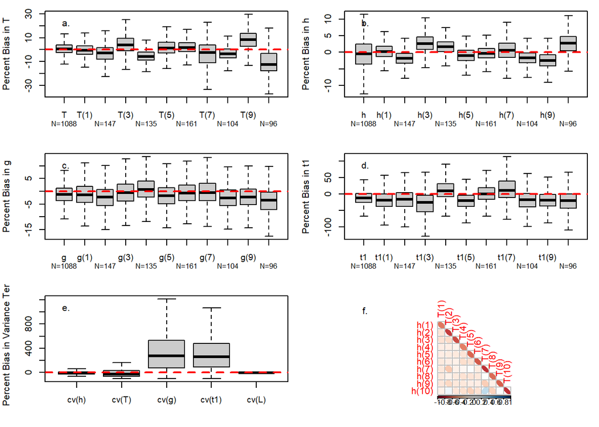

```r
par(mfrow = c(1, 1))
par(mar = c(4, 4, 1, 1))
layout(matrix(c(1, 2, 3, 4, 5, 6), nrow = 3, ncol = 2, byrow = TRUE))

boxplot(Tbias, ylab = "Percent Bias in T", col = "grey80", outline = FALSE,
    xaxt = "n")
axis(1, 1:(length(Tmat_i) + 1), c("T", paste("T(", 1:nPop, ")", sep = "")),
    line = 0, cex.axis = 0.9)
axis(1, 1:(length(Tmat_i) + 1), paste("N=", c(Ntot, Npop), sep = ""), line = 0.75,
    tick = F, cex.axis = 0.8)

abline(h = 0, lty = 2, col = "red", lwd = 2)
Corner_text("a.", "topleft")

boxplot(hBias, ylab = "Percent Bias in h", col = "grey80", outline = FALSE,
    xaxt = "n")
axis(1, 1:(length(h_i) + 1), c("h", paste("h(", 1:nPop, ")", sep = "")), cex.axis = 0.9)
axis(1, 1:(length(Tmat_i) + 1), paste("N=", c(Ntot, Npop), sep = ""), line = 0.75,
    tick = F, cex.axis = 0.8)
abline(h = 0, lty = 2, col = "red", lwd = 2)
Corner_text("b.", "topleft")

boxplot(gBias, ylab = "Percent Bias in g", col = "grey80", outline = FALSE,
    xaxt = "n")
axis(1, 1:(length(g_i) + 1), c("g", paste("g(", 1:nPop, ")", sep = "")), cex.axis = 0.9)
axis(1, 1:(length(Tmat_i) + 1), paste("N=", c(Ntot, Npop), sep = ""), line = 0.75,
    tick = F, cex.axis = 0.8)
abline(h = 0, lty = 2, col = "red", lwd = 2)
Corner_text("c.", "topleft")

boxplot(t1Bias, ylab = "Percent Bias in t1", col = "grey80", outline = FALSE,
    xaxt = "n")
axis(1, 1:(length(t1_i) + 1), c("t1", paste("t1(", 1:nPop, ")", sep = "")),
    cex.axis = 0.9)
axis(1, 1:(length(Tmat_i) + 1), paste("N=", c(Ntot, Npop), sep = ""), line = 0.75,
    tick = F, cex.axis = 0.8)
abline(h = 0, lty = 2, col = "red", lwd = 2)
Corner_text("d.", "topleft")

boxplot(varBias, ylab = "Percent Bias in Variance Terms", col = "grey80", outline = FALSE,
    xaxt = "n")
axis(1, 1:length(c(h_cv, Tmat_cv, g_cv, t1_cv, cv)), c("cv(h)", "cv(T)", "cv(g)",
    "cv(t1)", "cv(L)"), cex.axis = 0.9)
abline(h = 0, lty = 2, col = "red", lwd = 2)
Corner_text("e.", "topleft")

corr.mat <- res.corr[5:14, 15:24]
name1 <- name2 <- c()
for (i in 1:nPop) {
    name1[i] <- paste("h(", i, ")", sep = "")
    name2[i] <- paste("T(", i, ")", sep = "")
}
rownames(corr.mat) <- name1
colnames(corr.mat) <- name2
corrplot(corr.mat, is.corr = TRUE, method = "ellipse", mar = c(2, 4, 1, 0),
    type = "lower", diag = T)

Corner_text("f.", "topleft")
```

## Posterior predictive checks

Next, we will run posterior predictive checks, which use the posterior distribution of the parameter estimates to re-generate a randomized posterior distribution of data, assuming the data arose according to the truncated normal distribution (as specified in the model above). We then overlay our observed data atop this distribution to check if there is any systematic bias (Gelman *et al.* (2013)).

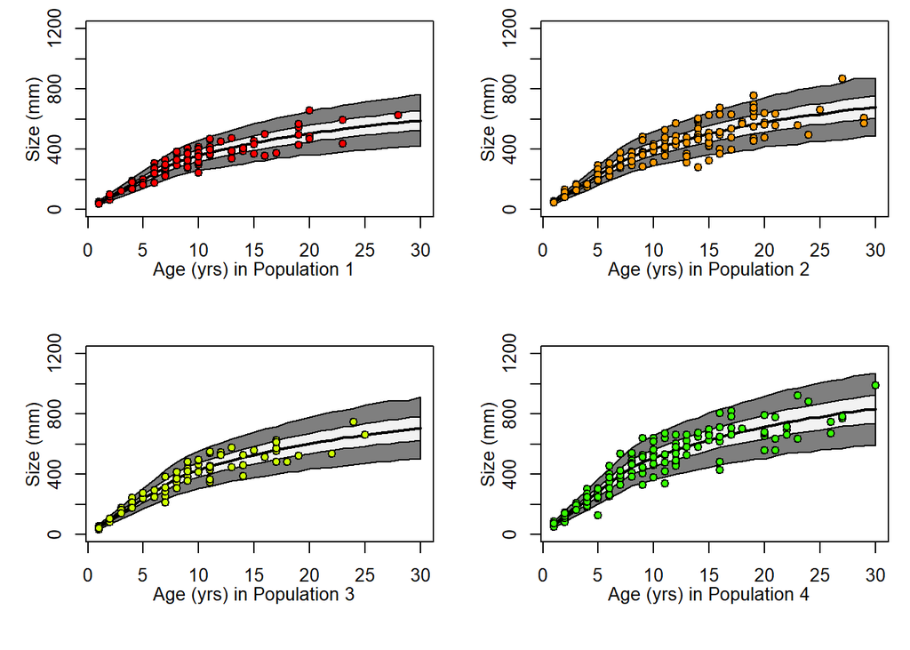

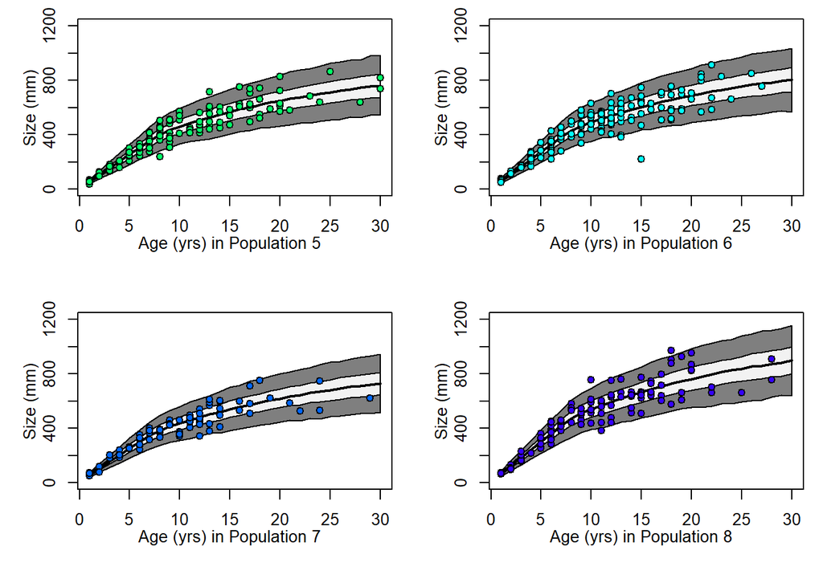

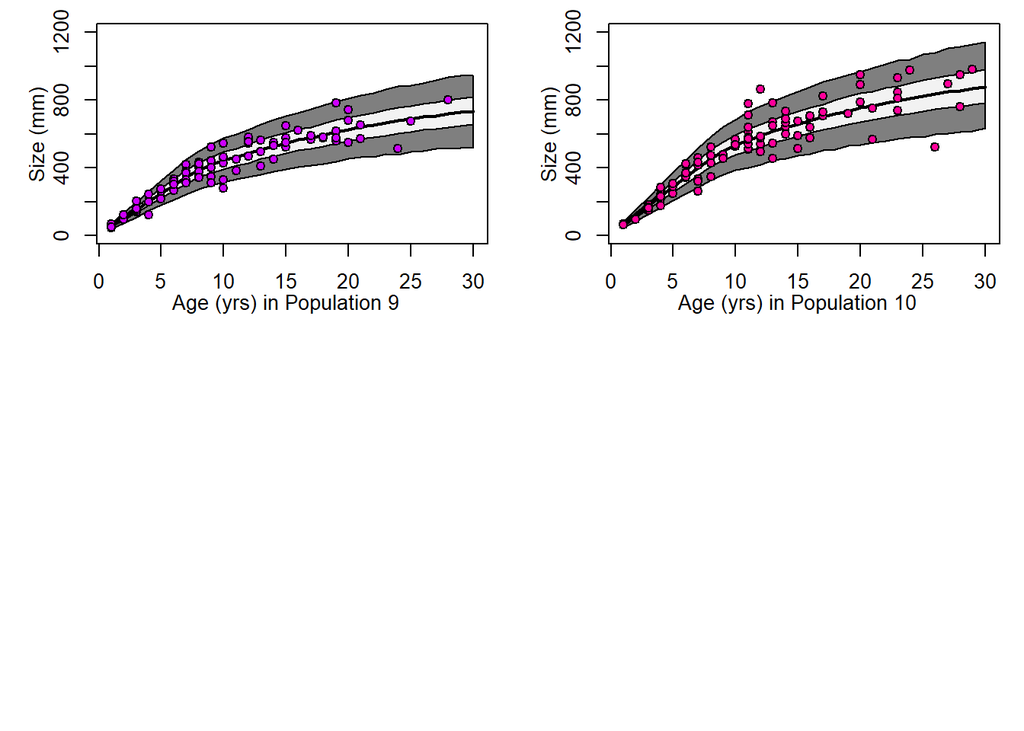

```r
age_vec <- c(ages, rev(ages))
post_pred <- array(NA, dim = c(nrow(TheRes), length(ages), nPop))
# Above code creates an empty array to track size-at-age for population i
# for posterior draw j
par(mfrow = c(1, 1))
par(mar = c(5, 4, 1, 1))
layout(matrix(c(1, 2, 3, 4), nrow = 2, ncol = 2, byrow = TRUE))
for (i in 1:nPop) {
    subbed <- subset(dataPop, dataPop$Pop_Num == i)
    for (j in 1:nrow(TheRes)) {
        h_j <- TheRes[j, match(paste("h_pop", "[", i, "]", sep = ""), colnames(TheRes))]
        g_j <- TheRes[j, match(paste("g_pop", "[", i, "]", sep = ""), colnames(TheRes))]
        T50_j <- TheRes[j, match(paste("T50_pop", "[", i, "]", sep = ""), colnames(TheRes))]
        t1_j <- TheRes[j, match(paste("t1_pop", "[", i, "]", sep = ""), colnames(TheRes))]
        cv_j <- TheRes[j, match("size.cv", colnames(TheRes))]

        linf <- 3 * h_j/g_j  # conversion for the VBGF L-infinity
        vbk <- log(1 + g_j/3)  # conversion for the VBGF parameter kappa
        t0 <- T50_j + log(1 - g_j * (T50_j - t1_j)/3)/log(1 + g_j/3)  #conversion for the VBGF parameter t0


        juv_j <- h_j * (ages - t1_j)
        adult_j <- linf * (1 - exp(-vbk * (ages - t0)))
        pred_j <- ifelse(ages < T50_j, juv_j, adult_j)
        pred_j[pred_j < 0.001] <- 0.001
        post_pred[j, , i] <- rnorm(length(ages), pred_j, pred_j * cv_j)
    }
    quants <- t(apply(post_pred[, , i], 2, FUN = quantile, probs = c(0.025,
        0.225, 0.5, 0.775, 0.975)))
    plot(age_vec, c(quants[, 1], rev(quants[, 5])), type = "l", lwd = 2, col = NA,
        ylab = "", xlab = "", ylim = c(0, 1200))
    axis(1, at = median(c(0, max(ages))), paste("Age (yrs) in ", "Population ",
        i, sep = ""), tick = FALSE, line = 0.9)
    axis(2, at = 600, "Size (mm)", tick = FALSE, line = 1)
    polygon(age_vec, c(quants[, 1], rev(quants[, 5])), col = "grey50")
    polygon(age_vec, c(quants[, 2], rev(quants[, 4])), col = "grey95")
    lines(ages, quants[, 3], lwd = 2, col = "black")
    points(subbed$Age, subbed$Size, pch = 21, bg = rainbow(nPop)[i])
}
```

## Trait-environment relationship

Finally, we will plot the environmental trend on $h$. In our model, we used an inclusion parameter $\omega$ (Royle & Dorazio (2008)) which told the MCMC algorithm to sample $\beta$ only when there was information in the posterior such that the Bernoulli trial on $\omega$ was equal to 1. Hence, we must remove all $\beta$ when $\omega$ equals 0 for our inference on the distribution of the slope term.

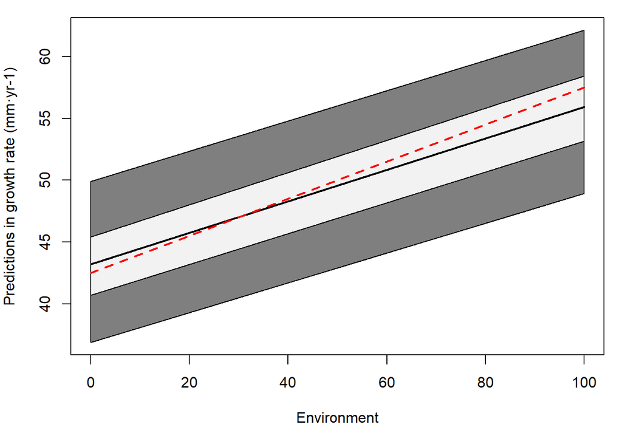

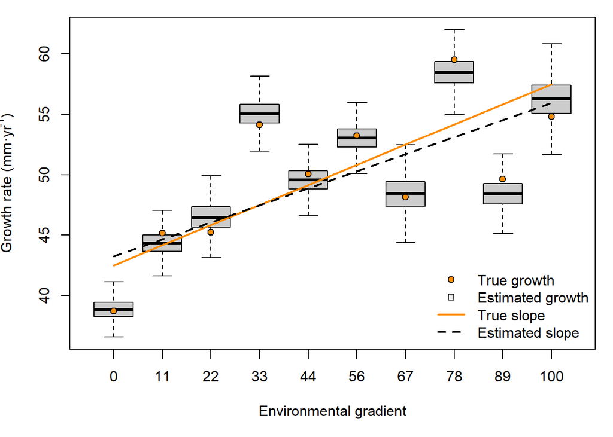

```r
layout(matrix(1, nrow = 1, ncol = 1))
par(mar = c(5, 4, 1, 1))
beta.hat <- sapply(TheRes[, "beta1"], FUN = function(x) {
    x * std.enviro
})
predRes <- beta.hat + TheRes[, "h"]
predRes <- predRes[, TheRes[, "wb"] != 0]
newEnviro <- seq(from = min(enviro), to = max(enviro), length = 2)
newStdEnviro <- newEnviro - mean(newEnviro)
beta.hat <- sapply(TheRes[, "beta1"], FUN = function(x) {
    x * newStdEnviro
})
predRes <- beta.hat + TheRes[, "h"]
predRes <- predRes[, TheRes[, "wb"] != 0]
betaQuants <- t(apply(predRes, 1, FUN = quantile, probs = c(0.025, 0.225, 0.5,
    0.775, 0.975)))
enviroRev <- c(newEnviro, rev(newEnviro))

plot(newEnviro, betaQuants[, 3], type = "l", ylim = range(betaQuants), xlab = "Environment",
    ylab = "Predictions in growth rate (mm·yr-1)")
polygon(enviroRev, c(betaQuants[, 1], rev(betaQuants[, 5])), col = "grey50")
polygon(enviroRev, c(betaQuants[, 2], rev(betaQuants[, 4])), col = "grey95")
lines(newEnviro, betaQuants[, 3], lty = 1, lwd = 2)
lines(newEnviro, beta1 * newStdEnviro + h, lty = 2, col = 2, lwd = 2)

boxplot(t(TheRes[, grep("h_pop", colnames(TheRes))]) ~ enviro, xaxt = "n", xlab = "Environmental gradient",
    ylab = expression(paste("Growth rate (mm·yr"^"-1", ")")), outline = F, col = "grey80")
axis(1, at = 1:10, round(enviro))
lines(1:nPop, beta1 * std.enviro + h, lty = 1, col = "darkorange", lwd = 2)
lines(c(1, nPop), betaQuants[, 3], lty = 2, lwd = 2, col = "black")
points(1:nPop, h_i, pch = 21, bg = "darkorange")
legend("bottomright", bty = "n", lty = c(NA, NA, 1, 2), pch = c(21, 22, NA,
    NA), pt.bg = c("darkorange", "grey95", NA, NA), lwd = c(NA, NA, 2, 2), c("True growth",
    "Estimated growth", "True slope", "Estimated slope"), col = c(1, 1, "darkorange",
    "black"))
```

## References

Denwood, M.J. (2016). runjags: An R package providing interface utilities, model templates, parallel computing methods and additional distributions for MCMC models in JAGS. *Journal of Statistical Software*, **71**, 1–25.

Gelman, A., Carlin, J., Stern, H., Dunson, D., Vehtari, A. & Rubin, D. (2013). *Bayesian Data Analysis*, 3rd edn. Chapman and Hall/CRC Press.

Helser, T.E. & Lai, H.-L. (2004). A bayesian hierarchical meta-analysis of fish growth: With an example for north american largemouth bass, micropterus salmoides. *Ecological Modelling*, **178**, 399–416.

Lester, N.P., Shuter, B.J. & Abrams, P.A. (2004). Interpreting the von bertalanffy model of somatic growth in fishes: The cost of reproduction. *Proceedings of the Royal Society B: Biological Sciences*, **271**, 1625–1631.

Lorenzen, K. (2016). Toward a new paradigm for growth modeling in fisheries stock assessments: Embracing plasticity and its consequences. *Fisheries Research*, **180**, 4–22.

Plummer, M. (2017). JAGS: A program for analysis of bayesian graphical models using gibbs sampling.

Plummer, M., Best, N., Cowles, K. & Vines, K. (2006). CODA: Convergence diagnosis and output analysis for mcmc. *R News*, **6**, 7–11.

Royle, J.A. & Dorazio, R.M. (2008). *Hierarchical modeling and inference in ecology: the analysis of data from populations, metapopulations and communities*. Academic Press.

Wilson, K.L., Honsey, A., Moe, B. & Venturelli, P. (2017). Growing the biphasic framework: techniques and recommendations for fitting emerging growth models. *Methods in Ecology and Evolution*, **In Review**.